# Лабораторная работа №4

Линейная алгебра

Ко Антон Геннадьевич

antonkosakh@gmail.com

Российский университет дружбы народов

2026-10-24

# Информация

## Докладчик

- Ко Антон Геннадьевич
- студент
- Российский университет дружбы народов им. П. Лумумбы
- 1132221551@rudn.ru
- https://SenDerMen04.github.io/ru/

## 1. Цель работы

Основной целью работы является изучение возможностей специализированных пакетов Julia для выполнения и оценки эффективности операций над объектами линейной алгебры.

## 2. Выполнение лабораторной работы

### 2.1 Поэлементные операции над многомерными массивами

Для матрицы 4 × 3 рассмотрим поэлементные операции сложения и произведения её элементов (рис. #fig:001):

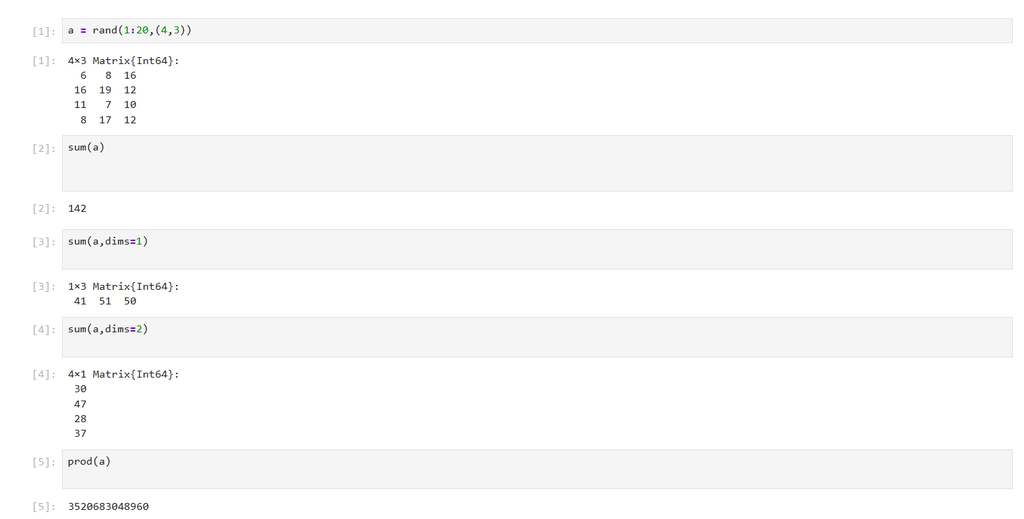

Поэлементные операции сложения и произведения элементов матрицы

Для работы со средними значениями можно воспользоваться возможностями пакета Statistics (рис. #fig:002):

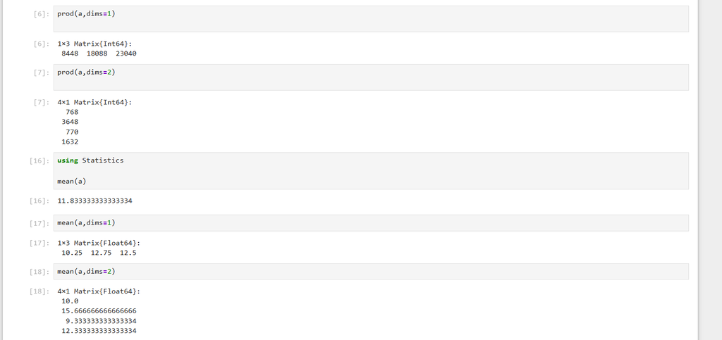

Использование возможностей пакета Statistics для работы со средними значениями

### 2.2 Транспонирование, след, ранг, определитель и инверсия матрицы

Для выполнения таких операций над матрицами, как транспонирование, диагонализация, определение следа, ранга, определителя матрицы и т.п. можно воспользоваться библиотекой (пакетом) LinearAlgebra (рис. #fig:003 – #fig:004):

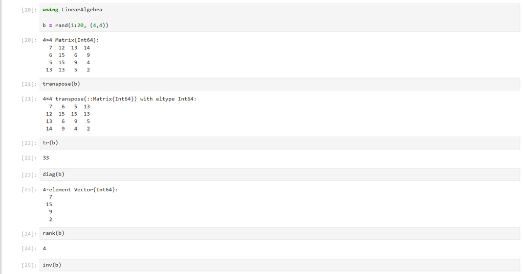

Использование библиотеки LinearAlgebra для выполнения определённых операций

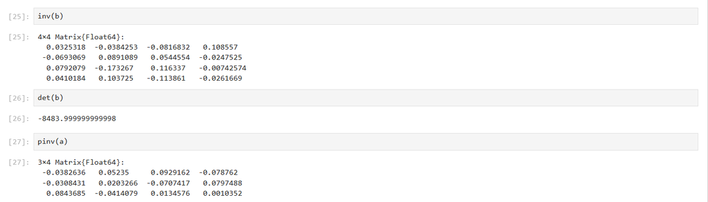

Использование библиотеки LinearAlgebra для выполнения определённых операций

### 2.3 Вычисление нормы векторов и матриц, повороты, вращения

Для вычисления нормы используется LinearAlgebra.norm(x) (рис. #fig:005):

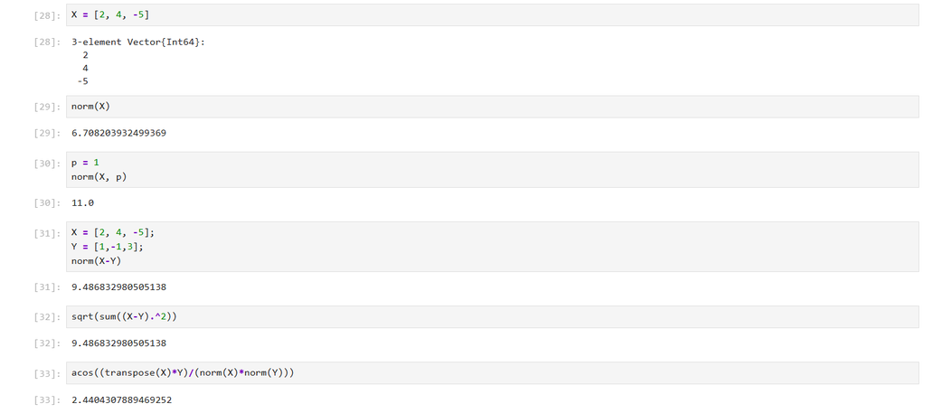

Использование LinearAlgebra.norm(x)

Вычислим нормы для двумерной матрицы (рис. #fig:006):

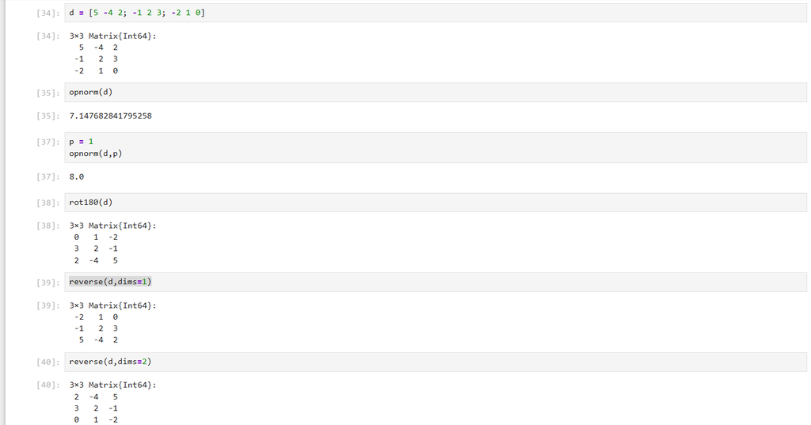

Вычисление нормы для двумерной матрицы

### 2.4 Матричное умножение, единичная матрица, скалярное произведение

Выполним примеры матричного умножения, единичной матрицы и скалярного произведения (рис. #fig:007):

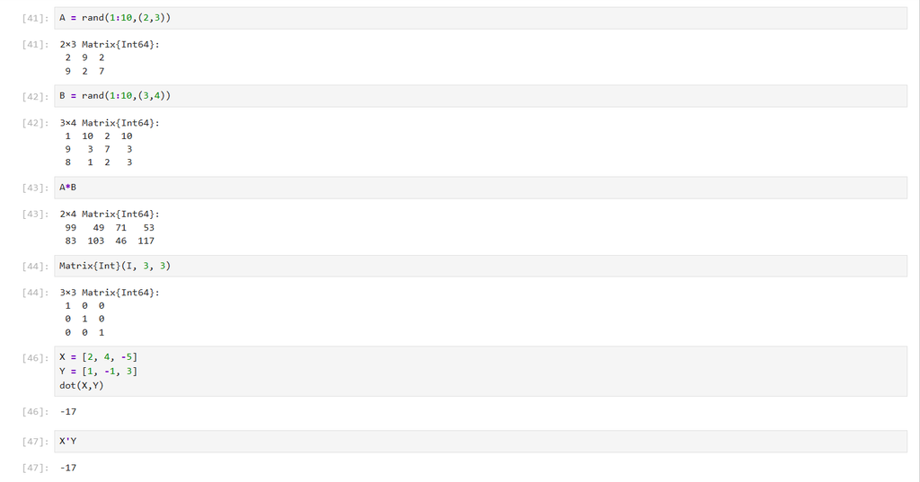

Примеры матричного умножения, единичной матрицы и скалярного произведения

### 2.5 Факторизация. Специальные матричные структуры

Решение систем линейных алгебраических уравнений (рис. #fig:008):

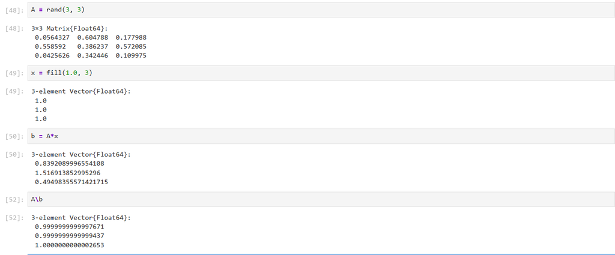

Решение систем линейных алгебраических уравнений

Julia позволяет вычислять LU-факторизацию и определяет составной тип факторизации для его хранения (рис. #fig:009):

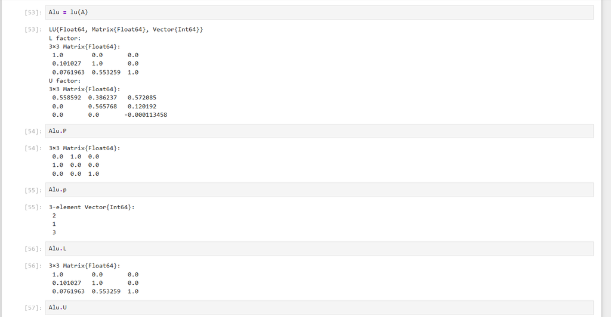

Пример вычисления LU-факторизации и определение составного типа факторизации для его хранения

Исходная система уравнений может быть решена или с использованием исходной матрицы, или с использованием объекта факторизации (рис. #fig:010):

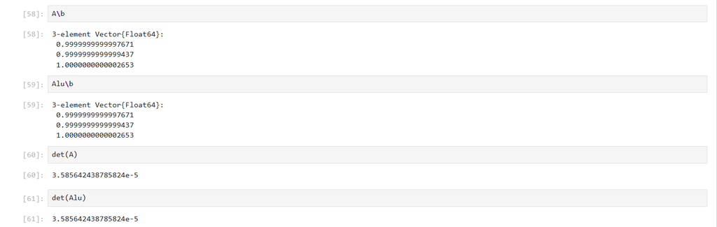

Пример решения с использованием исходной матрицы и с использованием объекта факторизации

Julia позволяет вычислять QR-факторизацию и определяет составной тип факторизации для его хранения (рис. #fig:011):

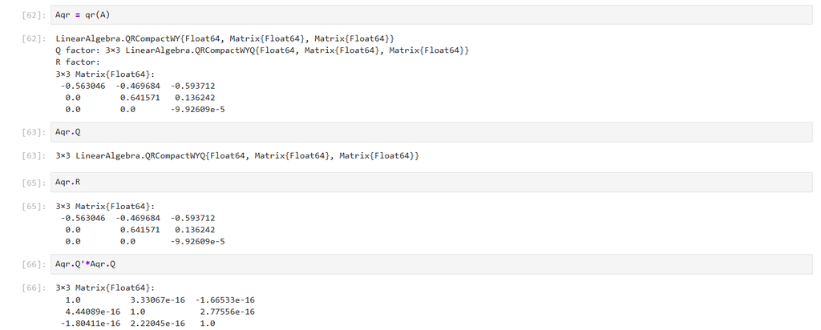

Пример вычисления QR-факторизации и определение составного типа факторизации для его хранения

Примеры собственной декомпозиции матрицы (рис. #fig:012):

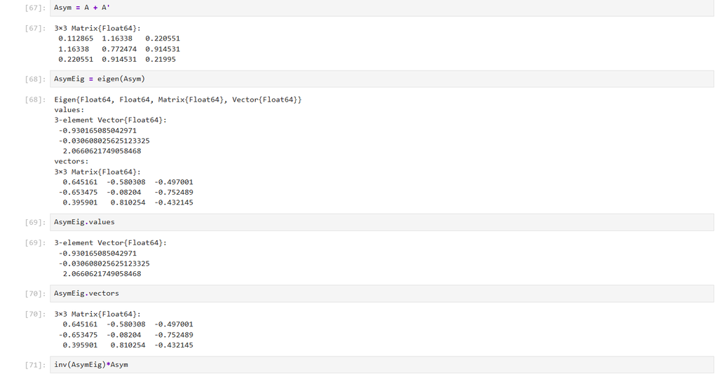

Примеры собственной декомпозиции матрицы

Далее рассмотрим примеры работы с матрицами большой размерности и специальной структуры (рис. #fig:013):

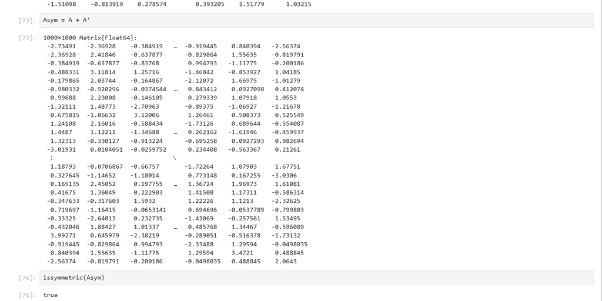

Примеры работы с матрицами большой размерности и специальной структуры

Пример добавления шума в симметричную матрицу (матрица уже не будет симметричной) (рис. #fig:014):

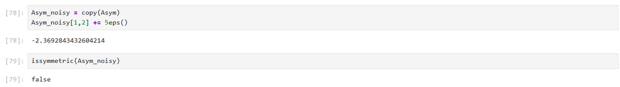

Пример добавления шума в симметричную матрицу

В Julia можно объявить структуру матрицы явно, например, используя Diagonal, Triangular, Symmetric, Hermitian, Tridiagonal и SymTridiagonal (рис. #fig:015):

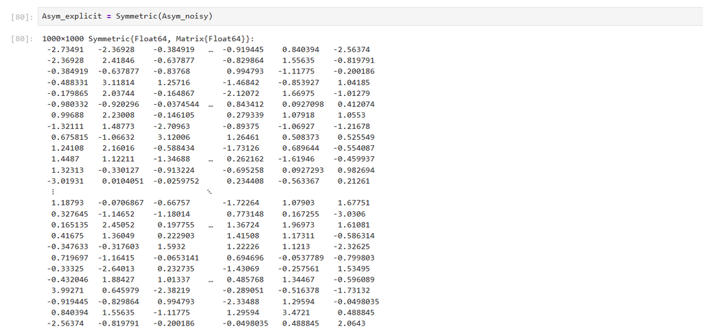

Пример явного объявления структуры матрицы

Далее для оценки эффективности выполнения операций над матрицами большой размерности и специальной структуры воспользуемся пакетом BenchmarkTools (рис. #fig:016):

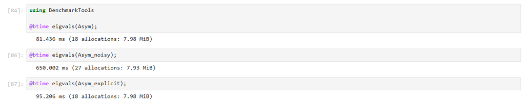

Использование пакета BenchmarkTools

Далее рассмотрим примеры работы с разреженными матрицами большой размерности. Использование типов Tridiagonal и SymTridiagonal для хранения трёхдиагональных матриц позволяет работать с потенциально очень большими трёхдиагональными матрицами (рис. #fig:017):

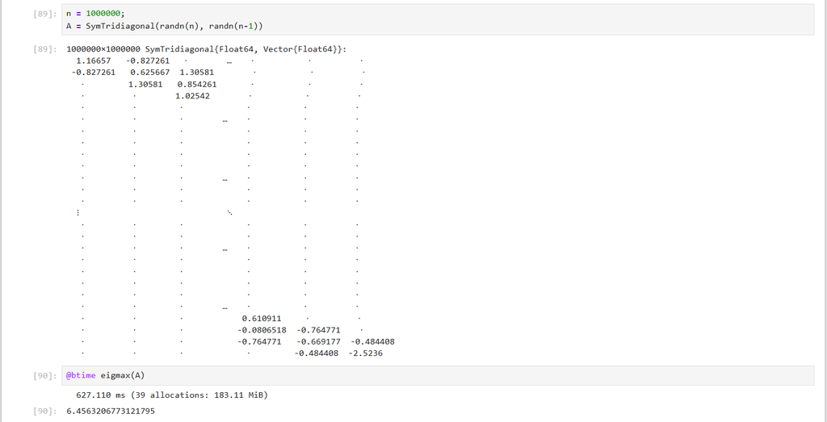

Примеры работы с разреженными матрицами большой размерности

### 2.6 Общая линейная алгебра

В примере показано, как можно решить систему линейных уравнений с рациональными элементами без преобразования в типы элементов с плавающей запятой (для избежания проблемы с переполнением используем BigInt) (рис. #fig:018):

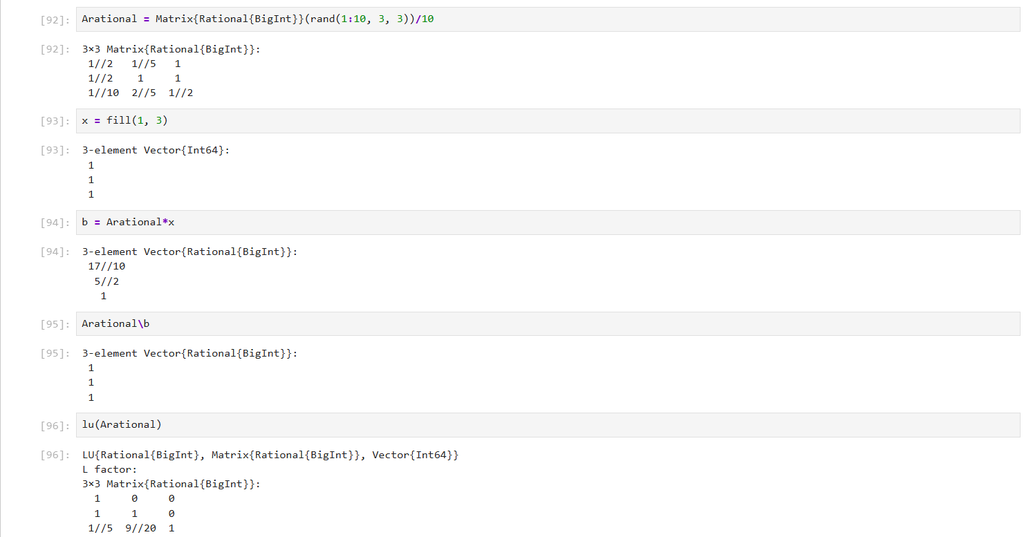

Решение системы линейных уравнений с рациональными элементами без преобразования в типы элементов с плавающей запятой

### 2.7 Самостоятельная работа

**Выполнение задания «Произведение векторов»** (рис. #fig:019):

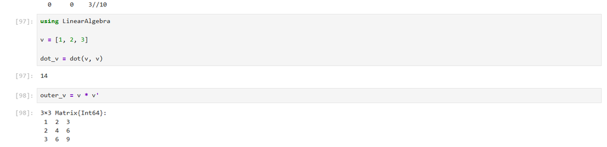

Решение задания «Произведение векторов»

**Выполнение задания «Системы линейных уравнений»** (рис. #fig:020 – #fig:021):

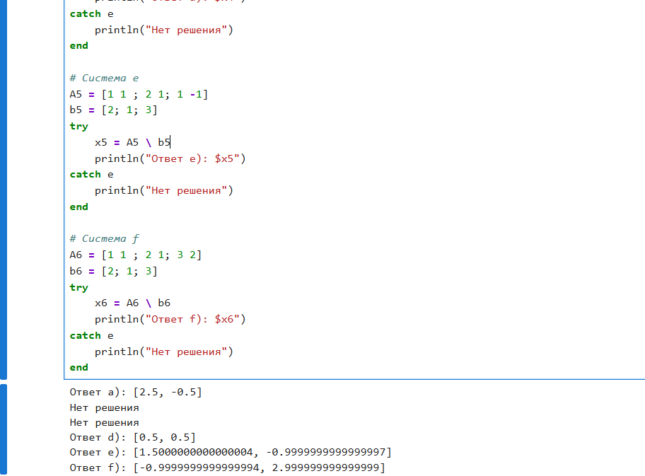

Решение задания «Системы линейных уравнений»

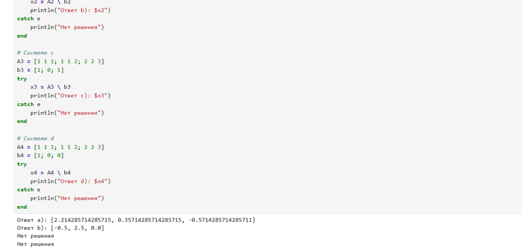

Решение задания «Системы линейных уравнений»

**Выполнение задания «Операции с матрицами»** (рис. #fig:022 – #fig:026):

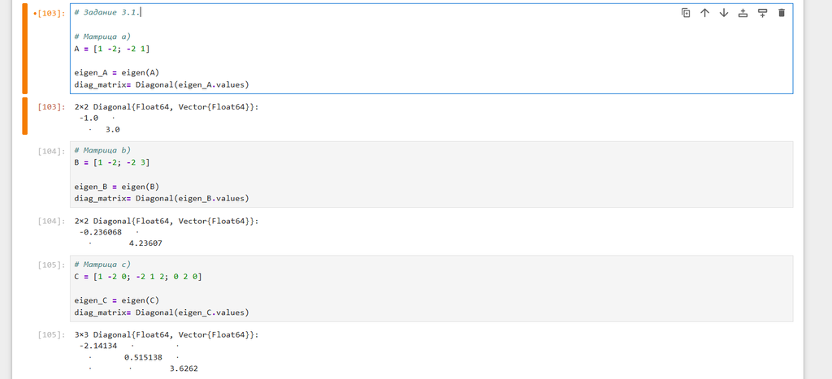

Решение задания «Операции с матрицами»

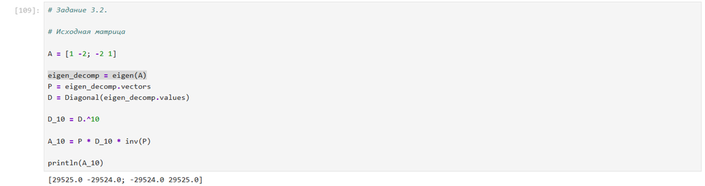

Решение задания «Операции с матрицами»

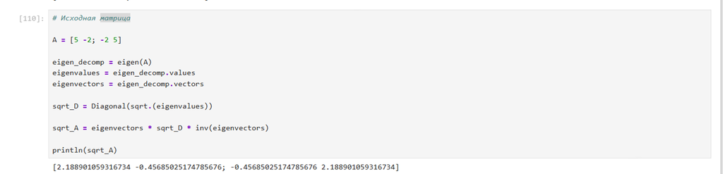

Решение задания «Операции с матрицами»

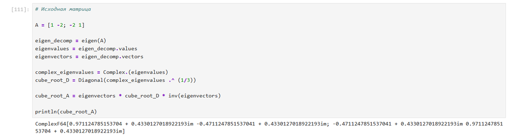

Решение задания «Операции с матрицами»

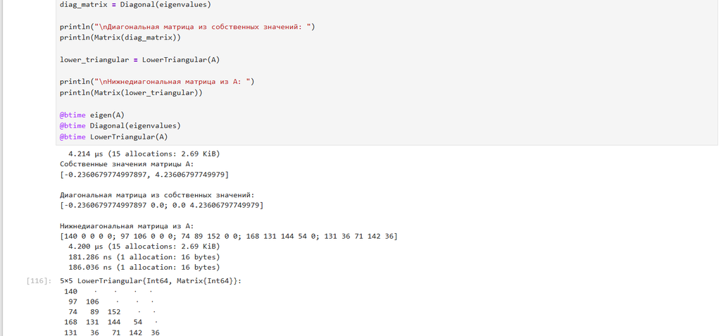

Решение задания «Операции с матрицами»

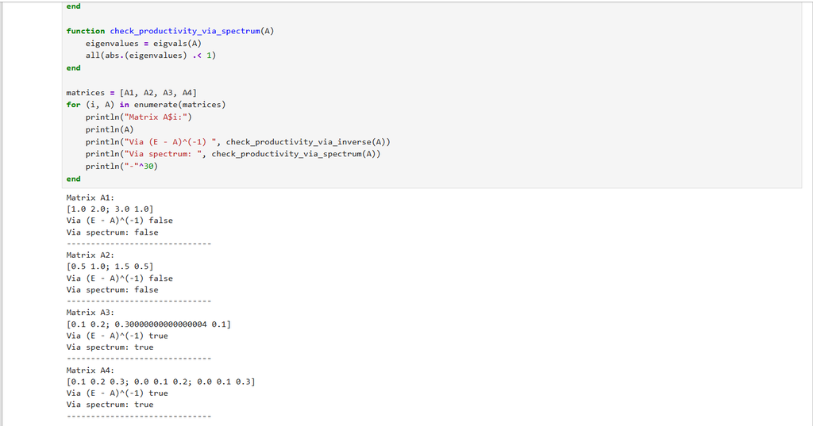

Решение задания «Линейные модели экономики»

## 3. Вывод

В ходе выполнения лабораторной работы были изучены возможности специализированных пакетов Julia для выполнения и оценки эффективности операций над объектами линейной алгебры.